# MATH201A_Week5_Lecture

TAO XU

2025-11-10

## Lecture 7

- **Midterm 1:** Thursday, *October 23rd*.

## Recall: Regularity of Lebesgue–Stieltjes Measures

**Theorem (Regularity of L–S Measures).**  
Suppose $F : \mathbb{R} \to \mathbb{R}$ is nondecreasing and right-continuous.  
For each $E \in \mathcal{M}_{\mu_F^*}$,

**(★) Outer Regularity:**
$$\mu_F(E) = \inf \{ \mu_F(U) : E \subseteq U,~U~\text{open} \},$$

**(★★) Inner Regularity:**
$$\mu_F(E) = \sup \{ \mu_F(K) : K \subseteq E,~K~\text{compact} \}.$$

## Integration

### Measurable Functions

Given $f : X \to Y$ and $E \subseteq Y$,
$$f^{-1}(E) = \{ x \in X : f(x) \in E \}.$$

### Recall from HW1

$$f^{-1}\left( \bigcup_{\alpha} E_{\alpha} \right)
= \bigcup_{\alpha} f^{-1}(E_{\alpha}),
\quad
f^{-1}\left( \bigcap_{\alpha} E_{\alpha} \right)
= \bigcap_{\alpha} f^{-1}(E_{\alpha}),
\quad
f^{-1}(E^c)
= (f^{-1}(E))^c.$$

### Measurable Spaces

Let $(X, \mathcal{M})$ and $(Y, \mathcal{N})$ be measurable spaces.  
Then the following are both σ-algebras:

1. $\{ f^{-1}(E) : E \in \mathcal{N} \}$ — *pullback of* $\mathcal{N}$;
2. $\{ E : f^{-1}(E) \in \mathcal{M} \}$ — *pushforward of* $\mathcal{M}$.

### Definition: Measurable Function

A function $f : X \to Y$ is $(\mathcal{M}, \mathcal{N})$-measurable
if, for every $E \in \mathcal{N}$,
$$f^{-1}(E) \in \mathcal{M}.$$

Equivalently:
$$\{ f^{-1}(E) : E \in \mathcal{N} \} \subseteq \mathcal{M}
\quad \Longleftrightarrow \quad
\{ E : f^{-1}(E) \in \mathcal{M} \} \supseteq \mathcal{N}.$$

### Important Case

When $f : X \to \mathbb{R}$,
we assume the **codomain** $\mathbb{R}$ is endowed with the **Borel σ-algebra**
$$\mathcal{B}_{\mathbb{R}}.$$

## Lebesgue and Borel Measurability

**Definition.**  
A function $f : \mathbb{R} \to \mathbb{R}$ is **Lebesgue measurable**  
if it is $(\mathcal{M}_{\lambda^*}, \mathcal{B}_{\mathbb{R}})$-measurable.

Given topological spaces $X, Y$,  
$f : X \to Y$ is **Borel measurable**  
if it is $(\mathcal{B}_X, \mathcal{B}_Y)$-measurable.

### Remark

For $f : \mathbb{R} \to \mathbb{R}$,
$$f~\text{Borel measurable} \implies f~\text{Lebesgue measurable}.$$

We will later see that
$$\mathcal{B}_{\mathbb{R}} \subsetneq \mathcal{M}_{\lambda^*}.$$

## Proposition

Let $(X, \mathcal{M})$ and $(Y, \mathcal{N})$ be measurable spaces  
and assume that $\mathcal{N}$ is generated by a collection $\mathcal{E}$.  
Then $f : X \to Y$ is $(\mathcal{M}, \mathcal{N})$-measurable  
**iff** for every $E \in \mathcal{E}$, $f^{-1}(E) \in \mathcal{M}$.

That is,
$$\mathcal{N} = \mathcal{M}(\mathcal{E}), \text{ the smallest σ-algebra
containing } \mathcal{E}.$$

### Notes

- Having $\mathcal{N} \subseteq \mathcal{M}(\mathcal{E})$ alone is **not** enough to imply the “⇒” direction.
- On the other hand, $\mathcal{E} \subseteq \mathcal{N}$ ensures $\mathcal{M}(\mathcal{E}) \subseteq \mathcal{N}$.

### Proof

Note that
$$\mathcal{E} \subseteq \{ E : f^{-1}(E) \in \mathcal{M} \}.$$
Since $\mathcal{N}$ is the **smallest σ-algebra** containing $\mathcal{E}$,
$$\mathcal{N} \subseteq \{ E : f^{-1}(E) \in \mathcal{M} \}.$$

## Corollaries

### Corollary 1

If $X$ and $Y$ are **topological spaces**,  
then every **continuous function** $f : X \to Y$ is **Borel measurable**.

**Proof.**  
Since $f$ is continuous, for every open $U \subseteq Y$,  
$f^{-1}(U)$ is open in $X$.  
Hence $f^{-1}(U) \in \mathcal{B}_X$.  
Because open sets generate $\mathcal{B}_Y$,  
the result follows from the previous proposition. ∎

### Corollary 2

If $(X, \mathcal{M})$ is a measurable space and $f : X \to \mathbb{R}$,
then $f$ is $(\mathcal{M}, \mathcal{B}_{\mathbb{R}})$-measurable
**iff** for all $a \in \mathbb{R}$,
$$f^{-1}((a, +\infty)) \in \mathcal{M}.$$

**Proof.**  
In HW3, you will show that the family  
$\{ (a, +\infty] : a \in \mathbb{R} \}$ generates $\mathcal{B}_{\mathbb{R}}$.  
Hence, this result follows directly from the above proposition. ∎

## Example: Constant Functions

**Question:**
If $(X,\mathcal{M})$ is a measurable space and $f:X\to\mathbb{R}$ is defined by
$$f(x)=c, \quad \forall x\in X, \text{ for some } c\in\mathbb{R},$$
is $f$ $(\mathcal{M},\mathcal{B}_{\mathbb{R}})$-measurable?

**Answer:** Yes.
For any $E\in\mathcal{B}_{\mathbb{R}}$,
$$f^{-1}(E)=
\begin{cases}
\varnothing, & c\notin E,\\[4pt]
X, & c\in E.
\end{cases}$$
Any σ-algebra $\mathcal{M}$ contains both $\varnothing$ and $X$, hence $f$ is measurable. ∎

## Theorem: Closure Properties of Measurable Functions

Fix a measurable space $(X,\mathcal{M})$, and let $\{f_i\}_{i=1}^{\infty}$ be  
functions $f_i:X\to\mathbb{R}$ that are $(\mathcal{M},\mathcal{B}_{\mathbb{R}})$-measurable.

Then the following functions are also measurable:

**(i)** $f_1+f_2$ (convention: $(+\infty)+(-\infty)=0$)

**(ii)** $f_1\cdot f_2$ (convention: $0\cdot(\pm\infty)=0$)

**(iii)** $f_1\vee f_2,\ f_1\vee f_2(x)=\max\{f_1(x),f_2(x)\}$

**(iv)** $f_1\wedge f_2,\ f_1\wedge f_2(x)=\min\{f_1(x),f_2(x)\}$

**(v)** $\sup_i f_i$

**(vi)** $\inf_i f_i$

**(vii)** $\limsup_{i\to\infty}f_i$

**(viii)** $\liminf_{i\to\infty}f_i$

**(ix)** $\lim_{i\to\infty}f_i$, whenever the pointwise limit exists.

### Proof

**(i)–(ii)** From HW4.

**(iii)** For any $a\in\mathbb{R}$,
$$(f_1\vee f_2)^{-1}((a,\infty))
= \{x\in X : (f_1\vee f_2)(x)>a\}
= \{f_1(x)>a\}\cup\{f_2(x)>a\}
= f_1^{-1}((a,\infty))\cup f_2^{-1}((a,\infty))\in\mathcal{M}.$$

**(iv)** Reduce to (iii) since
$$f_1\wedge f_2 = -\big((-f_1)\vee(-f_2)\big).$$

**(v)** For any $a\in\mathbb{R}$,
$$(\sup_i f_i)^{-1}((a,\infty))
= \bigcup_{i=1}^{\infty}\{x:f_i(x)>a\}
= \bigcup_{i=1}^{\infty}f_i^{-1}((a,\infty))\in\mathcal{M}.$$

**(vi)** Follows from (v) by applying the result to $-f_i$.

**(vii)** Recall
$$\limsup_{i\to\infty}f_i
= \lim_{N\to\infty}\sup_{i\ge N}f_i
= \inf_{N\in\mathbb{N}}\sup_{i\ge N}f_i.$$
Thus it is measurable by (v)–(vi).

**(viii)** $\liminf_{i\to\infty}f_i$ is measurable by symmetry.

**(ix)** If $\lim f_i = \limsup f_i = \liminf f_i$ exists,  
the limit function is measurable. ∎

## Remark: Composition of Measurable Functions

Let $f:\mathbb{R}\to\mathbb{R}$ and $g:\mathbb{R}\to\mathbb{R}$.

- If $f$ and $g$ are **Borel measurable**,
  then $f\circ g$ is **Borel measurable**, since
  $$(f\circ g)^{-1}(E) = g^{-1}(f^{-1}(E)).$$
- If $f$ is **Lebesgue measurable** and $g$ is **Borel measurable**,
  then $g\circ f$ is **Lebesgue measurable**, because
  $$(g\circ f)^{-1}(E) = f^{-1}(g^{-1}(E)).$$

## Key Idea of the Lebesgue Integral

The **Riemann integral** partitions the *domain* (the x-axis),  
while the **Lebesgue integral** partitions the *range* (the y-axis).

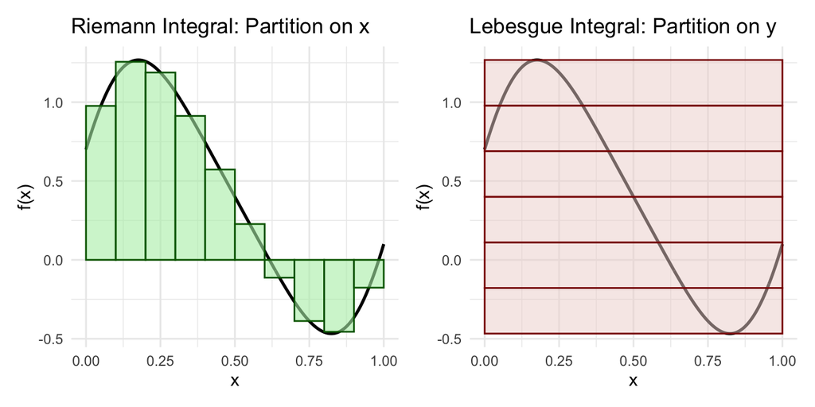

## Simple Functions

**Definition.** For any measurable set ($A \subseteq X$), the **indicator function** of A is
$$1_A(x) =
\begin{cases}
1, & x\in A, \\ 0, & \text{otherwise.}
\end{cases}$$

[figure not shown]

## When is an indicator function measurable?

$$1_A^{-1}(B) =
\begin{cases}
A, & 1 \in B, 0 \notin B \\
A^c, & 1 \notin B, 0 \in B \\
\varnothing, & 0,1 \notin B \\
X, & 0,1 \in B
\end{cases}$$

Thus, if $A \in \mathcal{M}$, the indicator function $1_A$ is $(\mathcal{M}, \mathcal{B}_\mathbb{R})$-measurable.

## Definition: Simple Measurable Functions

A function $f : X \to \mathbb{R}$ is **simple** (with respect to $(\mathcal{M}, \mathcal{B}_\mathbb{R})$)  
if the image set $f(X)$ is **finite**.

The **standard representation** of a simple function is:

$$f(x) = \sum_{i=1}^n c_i \, 1_{E_i}(x),$$

where
$$f(X) = \{ c_1, c_2, \ldots, c_n \} \quad \text{(distinct values)}, \quad
E_i = f^{-1}(c_i).$$

### ✅ End of Material for Midterm #1

# Lecture 8:

## Recall

Given a function $f : X \to Y$.  
Suppose $(X,\mathcal{M})$ and $(Y,\mathcal{N})$ are measurable spaces.  
Then the following collections are σ-algebras:

$$\{\, f^{-1}(E) : E \in \mathcal{N} \,\} \quad \text{("pull-back of
\(\mathcal{N}\)")},$$
$$\{\, E : f^{-1}(E) \in \mathcal{M} \,\} \quad \text{("push-forward
of \(\mathcal{M}\)")}.$$

## Definition

A function $f : X \to Y$ is $(\mathcal{M},\mathcal{N})$-measurable if
$$\forall\,E \in \mathcal{N}, \quad f^{-1}(E) \in \mathcal{M}.$$

### Important Case — Functions $f : X \to \mathbb{R}$

When $f : X \to \mathbb{R}$,  
we assume the range is endowed with the Borel σ-algebra $\mathcal{B}_{\mathbb{R}}$.

## Definitions of Borel and Lebesgue Measurable Functions

- $f : \mathbb{R} \to \mathbb{R}$ is **Lebesgue measurable**  
  if it is $(\mathcal{M}_\lambda, \mathcal{B}_{\mathbb{R}})$-measurable.
- For topological spaces $X,Y$,  
  $f : X \to Y$ is **Borel measurable**  
  if it is $(\mathcal{B}_X, \mathcal{B}_Y)$-measurable.

## Proposition and Corollaries

**Proposition:**
Let $(X,\mathcal{M})$ and $(Y,\mathcal{N})$ be measurable spaces where $\mathcal{N}$ is generated by a collection $\mathcal{E}$.
Then $f : X \to Y$ is $(\mathcal{M},\mathcal{N})$-measurable iff
$$\forall E \in \mathcal{E}, \quad f^{-1}(E) \in \mathcal{M}.$$

**Corollary 1:**  
If $X$ and $Y$ are topological spaces,  
then every continuous function $f : X \to Y$ is **Borel measurable**.

*Proof.* For any open set $U \subseteq Y$, $f^{-1}(U)$ is open,  
so $f^{-1}(U) \in \mathcal{B}_X.$ ∎

**Corollary 2:**
If $(X,\mathcal{M})$ is a measurable space and $f : X \to \mathbb{R}$, then
$f$ is $(\mathcal{M}, \mathcal{B}_{\mathbb{R}})$-measurable iff
$$\forall a \in \mathbb{R}, \quad f^{-1}((a,+\infty]) \in \mathcal{M}.$$

*(You proved in HW 3 that* $\{(a,+\infty] : a \in \mathbb{R}\}$ generates $\mathcal{B}_{\mathbb{R}}$.)

## Theorem: Operations Preserve Measurability

Fix a measurable space $(X,\mathcal{M})$ and measurable functions  
$\{ f_i \}_{i=1}^{\infty}$, where $f_i : X \to \overline{\mathbb{R}}$  
are $(\mathcal{M}, \mathcal{B}_{\overline{\mathbb{R}}})$-measurable.

Then the following functions are also measurable:

$$\begin{aligned}
\text{(i)} &\quad f_1 + f_2, \quad (+\infty) + (-\infty) := 0; \\
\text{(ii)} &\quad f_1 \cdot f_2, \quad 0 \cdot (\pm\infty) := 0;
\\
\text{(iii)} &\quad f_1 \vee f_2, \quad f_1 \vee f_2 (x) =
\max\{f_1(x), f_2(x)\}; \\
\text{(iv)} &\quad f_1 \wedge f_2, \quad f_1 \wedge f_2 (x) =
\min\{f_1(x), f_2(x)\}; \\
\text{(v)} &\quad \sup_i f_i, \\
\text{(vi)} &\quad \inf_i f_i, \\
\text{(vii)} &\quad \limsup_{i \to \infty} f_i, \\
\text{(viii)} &\quad \liminf_{i \to \infty} f_i, \\
\text{(ix)} &\quad \lim_{i \to \infty} f_i, \text{ whenever the
limit exists for all } x \in X.
\end{aligned}$$

## Simple Functions

### Definition

For any $A \subseteq X$, define the **indicator function**
$$1_A(x) :=
\begin{cases}
1, & x \in A,\\
0, & \text{otherwise.}
\end{cases}$$

A function $f : X \to \mathbb{R}$ is a **simple measurable function** if it is $(\mathcal{M}, \mathcal{B}_{\mathbb{R}})$-measurable  
and $f(X)$ is a **finite set**.

### Standard Representation

Every simple function $f$ can be expressed as

$$f(x) = \sum_{i=1}^{n} c_i \, 1_{E_i}(x),$$

where
$$f(X) = \{c_1, c_2, \ldots, c_n\} \text{ are distinct}, \quad
E_i = f^{-1}(c_i).$$

## Definition: Lebesgue Integral of a Simple Function

Let $(X, \mathcal{M}, \mu)$ be a measure space and
$f$ a **nonnegative simple function** with standard representation
$$f(x) = \sum_{i=1}^{n} c_i \, 1_{E_i}(x).$$

We define the **Lebesgue integral** of $f$ with respect to $\mu$ as

$$\int f \, d\mu := \sum_{i=1}^{n} c_i \, \mu(E_i),$$

with the convention $0 \cdot (+\infty) = 0.$

### Remarks

1. The definition depends only on the measurable sets $E_i$,  
   not on how $f$ is written.
2. If $f = c\,1_A$, then
   $$\int f\, d\mu = c\,\mu(A).$$
3. This serves as the **foundation** for defining integrals  
   of nonnegative measurable functions as limits of simple ones.

## Visualizing a Simple Function

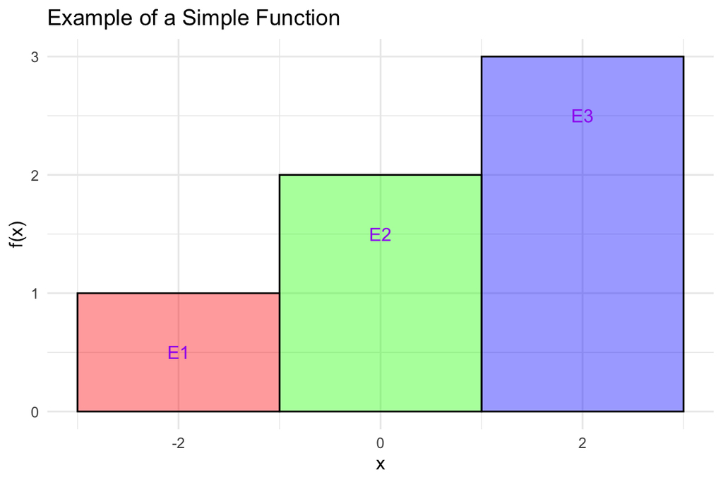

## Integration over a Measurable Subset

For any $A \in \mathcal{M}$, define
$$\int_A f \, d\mu := \int f \cdot 1_A \, d\mu.$$

### Example

If
$$f(x) =
\begin{cases}
1, & x \in [0,+\infty),\\
-1, & x \in (-\infty,0),
\end{cases}$$
then we **cannot** define
$$\int f\, d\lambda = 1\cdot \lambda([0,+\infty)) + (-1)\cdot
\lambda((-\infty,0))$$
since both terms are infinite — hence the integral is undefined.

This motivates starting integration theory with **nonnegative functions**.

## Notation for Integrals

$$\int f\, d\mu = \int f(x)\, d\mu(x)
= \int_X f(x)\, d\mu(x),
\quad
\int_A f\, d\mu = \int_A f(x)\, d\mu(x).$$

## Proposition — Basic Properties of Simple Integrals

Let $(X, \mathcal{M}, \mu)$ be a measure space  
and $f, g : X \to [0,+\infty)$ be simple functions. Then:

1. If $c \ge 0$,  
   $\displaystyle \int cf\, d\mu = c \int f\, d\mu.$
2. $\displaystyle \int (f+g)\, d\mu = \int f\, d\mu + \int g\, d\mu.$
3. If $f \le g$, then  
   $\displaystyle \int f\, d\mu \le \int g\, d\mu.$
4. For each fixed $f$, the mapping
   $$A \mapsto \int_A f\, d\mu$$
   defines a **measure** on $(X,\mathcal{M})$.

### Remarks

- Parts (1) and (2) guarantee that  
  the value of $\int f\, d\mu$ is **independent of representation**.
- If
  $$f = \sum_{i=1}^n c_i 1_{E_i}
  = \sum_{j=1}^m d_j 1_{F_j},$$
  with all $c_i, d_j \ge 0$ and $E_i, F_j$ measurable, then
  $$\int f\, d\mu
  = \sum_{i=1}^n c_i \mu(E_i)
  = \sum_{j=1}^m d_j \mu(F_j).$$

### Proof Sketch

Let $f = \sum_{i=1}^n a_i 1_{E_i}$,  
$g = \sum_{j=1}^m b_j 1_{F_j}$ be standard representations.

1. For $c>0$:
   $cf = \sum_i (c a_i)1_{E_i}$, hence
   $$\int cf\, d\mu = \sum_i c a_i \mu(E_i)
   = c \sum_i a_i \mu(E_i)
   = c \int f\, d\mu.$$
2. Additivity and monotonicity follow similarly.

## Example: Simple Function Structure

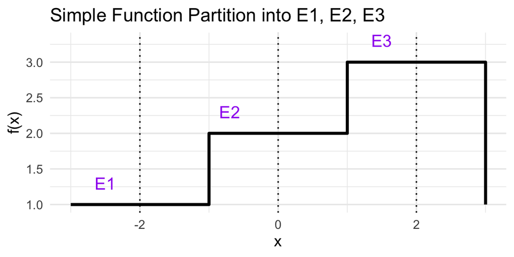

## Integration over a Measurable Subset

For $A \in \mathcal{M}$, define
$$\int_A f\, d\mu := \int f \cdot 1_A \, d\mu.$$

### Example

If
$$f(x) =
\begin{cases}
1, & x \in [0, +\infty),\\[4pt]
-1, & x \in (-\infty, 0),
\end{cases}$$
then we might wish to define
$$\int f\, d\lambda = 1 \cdot \lambda([0, +\infty)) + (-1) \cdot
\lambda((-\infty, 0)),$$
but both terms are infinite — so this expression is undefined. ☹️

### Motivation

This is why we begin our study of integration with **nonnegative functions only.** 🙂

## Notation for Integrals

$$\int f\, d\mu = \int f(x)\, d\mu(x) = \int_X f(x)\, d\mu(x),$$
and for measurable $A \subseteq X$,
$$\int_A f\, d\mu = \int_A f(x)\, d\mu(x).$$

## Proposition: Properties of the Simple Integral

Let $(X, \mathcal{M}, \mu)$ be a measure space and $f,g : X \to [0, +\infty)$ be simple functions.

1. If $c \ge 0$, then
   $$\int c f\, d\mu = c \int f\, d\mu.$$
2. For all simple $f, g$,
   $$\int (f+g)\, d\mu = \int f\, d\mu + \int g\, d\mu.$$
3. If $f \le g$, then
   $$\int f\, d\mu \le \int g\, d\mu.$$
4. The function
   $$A \mapsto \int_A f\, d\mu$$
   is a **measure** on $(X, \mathcal{M})$.

## Independence of Representation

Parts (1) and (2) ensure that  
$\int f\, d\mu$ does **not depend** on how $f$ is written  
as a nonnegative linear combination of indicator functions.

That is, if
$$f = \sum_{i=1}^{n} c_i \, 1_{E_i} = \sum_{j=1}^{m} d_j \, 1_{F_j},$$
where $c_i, d_j \ge 0$ and $E_i, F_j$ are measurable, then
$$\int f\, d\mu = \sum_{i=1}^{n} c_i \, \mu(E_i)
= \sum_{j=1}^{m} d_j \, \mu(F_j).$$

### Proof (Sketch)

Let $f = \sum_i a_i 1_{E_i}$ and $g = \sum_j b_j 1_{F_j}$.

- For $c > 0$,
  $$cf = \sum_i (c a_i) 1_{E_i} \implies
  \int c f\, d\mu = c \int f\, d\mu.$$
- Using **disjoint refinements** of $\{E_i\}$ and $\{F_j\}$, linearity follows from the definition of the integral.

### (2) Linearity of the Integral

Since the collections $\{E_i\}_{i=1}^n$ and $\{F_j\}_{j=1}^m$
form (disjoint) partitions of $X$, we have
$$E_i = \bigcup_{j=1}^m (E_i \cap F_j), \quad
F_j = \bigcup_{i=1}^n (F_j \cap E_i),$$
where the unions are **disjoint**.

Thus,
$$\int f\, d\mu + \int g\, d\mu
= \sum_{i=1}^n a_i\, \mu(E_i) + \sum_{j=1}^m b_j\, \mu(F_j).$$

Rewriting using the disjoint partitions:
$$\begin{aligned}
\int f\, d\mu + \int g\, d\mu
&= \sum_{i,j} a_i\, \mu(E_i \cap F_j) + \sum_{i,j} b_j\, \mu(E_i
\cap F_j) \\[4pt]
&= \sum_{i,j} (a_i + b_j)\, \mu(E_i \cap F_j).
\end{aligned}$$

Let $c_k = a_i + b_j$ and define
$$G_k := \bigcup_{i,j : a_i + b_j = c_k} (E_i \cap F_j),$$
so that the $c_k$ are **distinct** values and $\{G_k\}$ is a partition of $X$.

Then
$$\int (f+g)\, d\mu
= \sum_{k=1}^\ell c_k\, \mu(G_k)
= \sum_{i,j} (a_i + b_j)\, \mu(E_i \cap F_j)
= \int f\, d\mu + \int g\, d\mu.$$

Hence, **linearity holds**.

### (3) Monotonicity

If $f \le g$, then for all $E_i \cap F_j \ne \varnothing$, we have $a_i \le b_j$.

Thus,
$$\int f\, d\mu
= \sum_i a_i\, \mu(E_i)
= \sum_{i,j} a_i\, \mu(E_i \cap F_j)
\le \sum_{i,j} b_j\, \mu(E_i \cap F_j)
= \sum_j b_j\, \mu(F_j)
= \int g\, d\mu.$$

### (4) Defining a Measure via Integration

Let
$$\nu(A) := \int_A f\, d\mu.$$
Then $\nu$ is a **nonnegative function** on $\mathcal{M}$.

#### Step 1. Zero Measure on the Empty Set

$$\nu(\varnothing)
= \int_\varnothing f\, d\mu
= \int f \cdot 1_\varnothing\, d\mu
= 0.$$

#### Step 2. Countable Additivity

Let $\{A_k\}_{k=1}^\infty \subseteq \mathcal{M}$ be disjoint, and set
$$A := \bigcup_{k=1}^\infty A_k.$$

Then, using the standard representation $f = \sum_{i=1}^n a_i 1_{E_i}$,
$$\begin{aligned}
\nu(A)
&= \int_A f\, d\mu
= \int f 1_A\, d\mu
= \int \Big( \sum_{i=1}^n a_i 1_{E_i} \Big) 1_A\, d\mu \\[4pt]
&= \sum_{i=1}^n a_i \int 1_{E_i} 1_A\, d\mu
= \sum_{i=1}^n a_i\, \mu(E_i \cap A) \\[4pt]
&= \sum_{i=1}^n a_i \sum_{k=1}^\infty \mu(E_i \cap A_k)
= \sum_{k=1}^\infty \sum_{i=1}^n a_i\, \mu(E_i \cap A_k) \\[4pt]
&= \sum_{k=1}^\infty \int f 1_{A_k}\, d\mu
= \sum_{k=1}^\infty \int_{A_k} f\, d\mu
= \sum_{k=1}^\infty \nu(A_k).
\end{aligned}$$

Therefore, $\nu$ is **countably additive**,  
hence a **measure** on $(X, \mathcal{M})$.

### Conclusion

$$\nu(A) = \int_A f\, d\mu$$
defines a **measure** whenever $f$ is a nonnegative simple function.
This shows that integration with respect to $\mu$ generates a new measure $\nu$ absolutely continuous with respect to $\mu$.

## Integration of Nonnegative Measurable Functions

### Definition

Given a measure space $(X, \mathcal{M}, \mu)$ and a measurable function  
$f : X \to [0, +\infty]$, we define the **Lebesgue integral** of $f$ as

$$\int f\, d\mu := \sup \Big\{ \int \varphi\, d\mu : 0 \le \varphi \le f,
\, \varphi \text{ simple} \Big\}.$$

That is, the integral of $f$ is the supremum of the integrals of all simple functions $\varphi$ bounded above by $f$.

### Remarks

1. If $f$ is simple, this agrees with the previous definition.
2. **Homogeneity.**
   For any constant $c \ge 0$,
   $$\int cf\, d\mu = c \int f\, d\mu.$$

**Proof:**
$$\begin{aligned}
\int cf\, d\mu
&= \sup \Big\{ \int \varphi\, d\mu : 0 \le \varphi \le cf, \,
\varphi \text{ simple} \Big\} \\[4pt]
&= \sup \Big\{ \int c\psi\, d\mu : 0 \le \psi \le f, \, \psi \text{
simple} \Big\}
\quad (\text{letting } \psi = \tfrac{\varphi}{c}) \\[4pt]
&= \sup \Big\{ c \int \psi\, d\mu : 0 \le \psi \le f, \, \psi \text{
simple} \Big\} \\[4pt]
&= c \sup \Big\{ \int \psi\, d\mu : 0 \le \psi \le f, \, \psi \text{
simple} \Big\} \\[4pt]
&= c \int f\, d\mu.
\end{aligned}$$

3. **Monotonicity.**
   If $f \le g$, then
   $$\int f\, d\mu \le \int g\, d\mu.$$

### Intuition

This definition extends the integral from simple functions to all nonnegative measurable functions by taking the “limit from below.”  
The supremum ensures that the integral captures the *area under* $f$ as accurately as possible through approximations by simple functions.